# Clase 4

Pachá

June 19, 2016

# Ejercicio 1

En base a lo ya hecho con la base de datos *Swiss* (clase 2):

- Graficar las correlaciones
- Hacer una regresión de **fertilidad** versus **agricultura**
- Hacer una regresión de **fertilidad** versus todas las demás variables
- ¿Por qué cambia el signo del beta de **agricultura**?
- Crear una variable $z=agricultura+educación$ y repetir la regresión anterior ¿Qué ocurre?

## Correlaciones

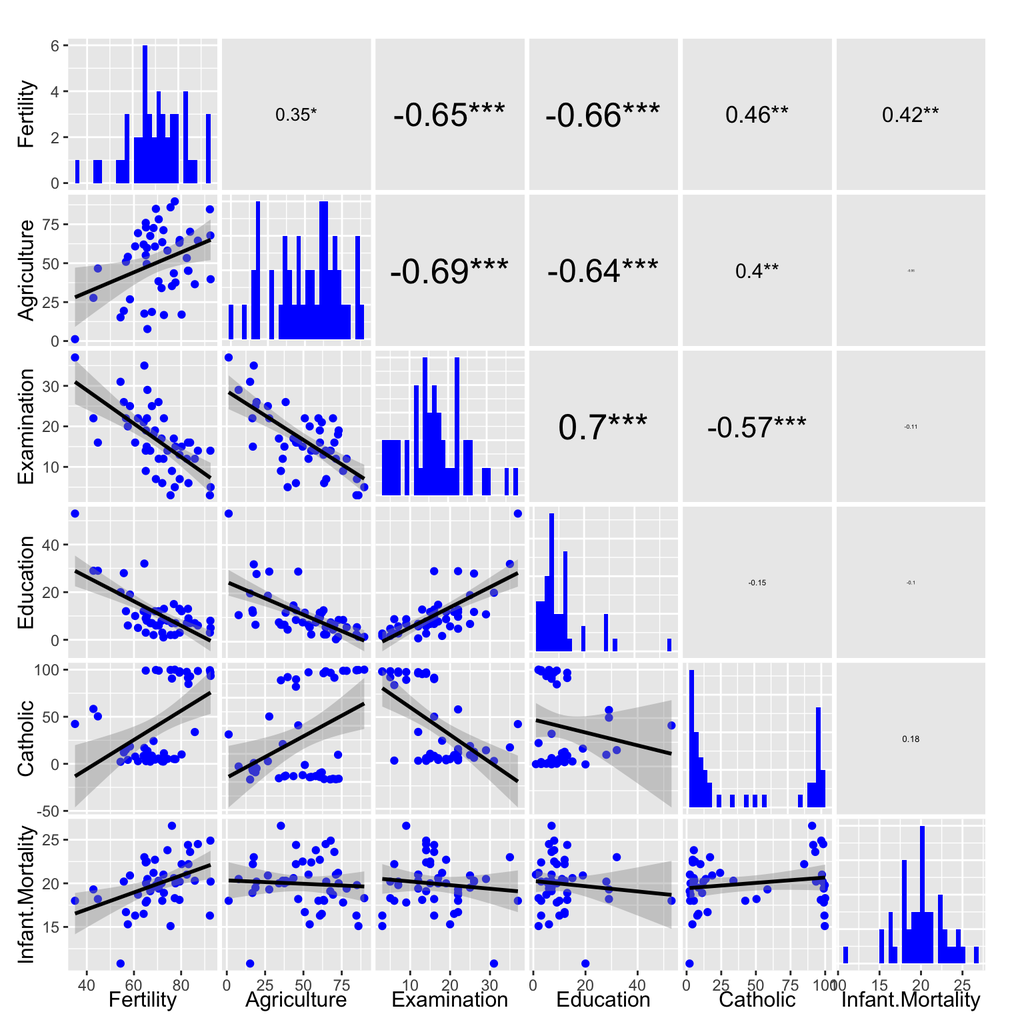

```r
source("ggally_mod.R")

ggpairs(swiss,
        lower=list(continuous=wrap("smooth", colour="blue")),
        diag=list(continuous=wrap("barDiag", fill="blue")),
        upper=list(continuous=cor_fun))
```

## Fertilidad versus agricultura

```r
summary(lm(Fertility ~ Agriculture, data = swiss))
```

```
##
## Call:
## lm(formula = Fertility ~ Agriculture, data = swiss)
##
## Residuals:
##      Min       1Q   Median       3Q      Max
## -25.5374  -7.8685  -0.6362   9.0464  24.4858
##
## Coefficients:
##             Estimate Std. Error t value Pr(>|t|)
## (Intercept) 60.30438    4.25126  14.185   <2e-16 ***
## Agriculture  0.19420    0.07671   2.532   0.0149 *
## ---
## Signif. codes:  0 '***' 0.001 '**' 0.01 '*' 0.05 '.' 0.1 ' ' 1
##
## Residual standard error: 11.82 on 45 degrees of freedom
## Multiple R-squared:  0.1247, Adjusted R-squared:  0.1052
## F-statistic: 6.409 on 1 and 45 DF,  p-value: 0.01492
```

## Fertilidad versus todas las demás variables

```r
summary(lm(Fertility ~ . , data = swiss))
```

```
##
## Call:
## lm(formula = Fertility ~ ., data = swiss)
##
## Residuals:
##      Min       1Q   Median       3Q      Max
## -15.2743  -5.2617   0.5032   4.1198  15.3213
##
## Coefficients:
##                  Estimate Std. Error t value Pr(>|t|)
## (Intercept)      66.91518   10.70604   6.250 1.91e-07 ***
## Agriculture      -0.17211    0.07030  -2.448  0.01873 *
## Examination      -0.25801    0.25388  -1.016  0.31546
## Education        -0.87094    0.18303  -4.758 2.43e-05 ***
## Catholic          0.10412    0.03526   2.953  0.00519 **
## Infant.Mortality  1.07705    0.38172   2.822  0.00734 **
## ---
## Signif. codes:  0 '***' 0.001 '**' 0.01 '*' 0.05 '.' 0.1 ' ' 1
##
## Residual standard error: 7.165 on 41 degrees of freedom
## Multiple R-squared:  0.7067, Adjusted R-squared:  0.671
## F-statistic: 19.76 on 5 and 41 DF,  p-value: 5.594e-10
```

## Variables irrelevantes

```r
swiss$z <- swiss$Agriculture + swiss$Education
summary(lm(Fertility ~ . , data = swiss))
```

```
##
## Call:
## lm(formula = Fertility ~ ., data = swiss)
##
## Residuals:
##      Min       1Q   Median       3Q      Max
## -15.2743  -5.2617   0.5032   4.1198  15.3213
##
## Coefficients: (1 not defined because of singularities)
##                  Estimate Std. Error t value Pr(>|t|)
## (Intercept)      66.91518   10.70604   6.250 1.91e-07 ***
## Agriculture      -0.17211    0.07030  -2.448  0.01873 *
## Examination      -0.25801    0.25388  -1.016  0.31546
## Education        -0.87094    0.18303  -4.758 2.43e-05 ***
## Catholic          0.10412    0.03526   2.953  0.00519 **
## Infant.Mortality  1.07705    0.38172   2.822  0.00734 **
## z                      NA         NA      NA       NA
## ---
## Signif. codes:  0 '***' 0.001 '**' 0.01 '*' 0.05 '.' 0.1 ' ' 1
##
## Residual standard error: 7.165 on 41 degrees of freedom
## Multiple R-squared:  0.7067, Adjusted R-squared:  0.671
## F-statistic: 19.76 on 5 and 41 DF,  p-value: 5.594e-10
```

# Ejercicio 2

Suponga que le encargan un estudio del rendimiento (ahorro de combustible) de distintos vehículos. La base de datos *mtcars* provee información de vehículos automáticos y mecánicos.

En base a esto responda

1. ¿Es la transmisión manual mejor que la automática en cuanto a kilómetros por litro?
2. ¿Cuál es la diferencia en kilómetros por litro entre vehículos mecánicos y automáticos?

# Desarrollo ejercicio

Primero veamos la ayuda y los datos

```r
#help(mtcars) esto se escribe directamente
data(mtcars)
head(mtcars)
```

```
##                    mpg cyl disp  hp drat    wt  qsec vs am gear carb
## Mazda RX4         21.0   6  160 110 3.90 2.620 16.46  0  1    4    4
## Mazda RX4 Wag     21.0   6  160 110 3.90 2.875 17.02  0  1    4    4
## Datsun 710        22.8   4  108  93 3.85 2.320 18.61  1  1    4    1
## Hornet 4 Drive    21.4   6  258 110 3.08 3.215 19.44  1  0    3    1
## Hornet Sportabout 18.7   8  360 175 3.15 3.440 17.02  0  0    3    2
## Valiant           18.1   6  225 105 2.76 3.460 20.22  1  0    3    1
```

Los datos están expresados en millas, galones y libras. Hay que convertir las unidades

```r
mtcars$mpg = mtcars$mpg * (1.609344/3.7854118)
mtcars$qsec = mtcars$qsec/1.609344
mtcars$wt = mtcars$wt*(0.45359237/1000)
```

Hay poca información de *vs* pero [stackoverflow](http://stackoverflow.com/questions/18617174/r-mtcars-dataset-meaning-of-vs-variable) da información al respecto. Se trata del tipo de motor.

Las variables categóricas se pueden arreglar e incorporar una etiqueta (será útil para graficar)

```r
mtcars$cyl<-factor(mtcars$cyl)
mtcars$vs<-factor(mtcars$vs, levels=c(0, 1), labels=c("motor S", "motor V"))
mtcars$am<-factor(mtcars$am, levels=c(0, 1), labels =c("automatico", "manual"))
mtcars$gear<-factor(mtcars$gear)
mtcars$carb<-factor(mtcars$carb)
```

## Probando modelos

$$Modelo 1:\: MPG_i = \beta_0 + \beta_1 CYL_i + \beta_2 DISP_i + \beta_3 HP_i + \beta_4 QSEC_i + \beta_5 VS_i + \beta_6 AM_i + \beta_4 GEAR_i + \beta_4 CARB_i + \varepsilon_i$$

$$Modelo 2:\: MPG_i = \beta_0 + \beta_1 AM_i + \varepsilon_i$$

$$Modelo 3:\: MPG_i = \beta_0 + \beta_1 AM_i + \beta_2 WT_i + \varepsilon_i$$

$$Modelo 4:\: MPG_i = \beta_0 + \beta_1 AM_i + \beta_2 WT_i + \beta_3 (AM_i\times WT_i) + \varepsilon_i$$

```r
fit1<-lm(mpg~., data=mtcars)
fit2<-lm(mpg~am, data=mtcars)
fit3<-lm(mpg~am+wt, data=mtcars)
fit4<-lm(mpg~am*wt, data=mtcars)
summary(fit1)
```

```
##
## Call:
## lm(formula = mpg ~ ., data = mtcars)
##
## Residuals:
##      Min       1Q   Median       3Q      Max
## -1.49171 -0.57751 -0.04031  0.32929  1.96631
##
## Coefficients:
##               Estimate Std. Error t value Pr(>|t|)
## (Intercept)  1.015e+01  8.531e+00   1.190   0.2525
## cyl6        -1.126e+00  1.293e+00  -0.871   0.3975
## cyl8        -1.429e-01  3.044e+00  -0.047   0.9632
## disp         1.511e-02  1.356e-02   1.114   0.2827
## hp          -2.998e-02  1.676e-02  -1.788   0.0939 .
## drat         5.029e-01  1.056e+00   0.476   0.6407
## wt          -4.246e+03  2.380e+03  -1.784   0.0946 .
## qsec         2.517e-01  6.400e-01   0.393   0.6997
## vsmotor V    8.209e-01  1.221e+00   0.672   0.5115
## ammanual     5.153e-01  1.366e+00   0.377   0.7113
## gear4        4.738e-01  1.615e+00   0.293   0.7733
## gear5        1.075e+00  1.588e+00   0.677   0.5089
## carb2       -4.164e-01  9.855e-01  -0.423   0.6787
## carb3        1.275e+00  1.825e+00   0.699   0.4955
## carb4        4.640e-01  1.892e+00   0.245   0.8096
## carb6        1.904e+00  2.714e+00   0.701   0.4938
## carb8        3.082e+00  3.554e+00   0.867   0.3995
## ---
## Signif. codes:  0 '***' 0.001 '**' 0.01 '*' 0.05 '.' 0.1 ' ' 1
##
## Residual standard error: 1.205 on 15 degrees of freedom
## Multiple R-squared:  0.8931, Adjusted R-squared:  0.779
## F-statistic:  7.83 on 16 and 15 DF,  p-value: 0.000124
```

```r
summary(fit2)
```

```
##
## Call:
## lm(formula = mpg ~ am, data = mtcars)
##
## Residuals:
##     Min      1Q  Median      3Q     Max
## -3.9931 -1.3147 -0.1264  1.3791  4.0421
##
## Coefficients:
##             Estimate Std. Error t value Pr(>|t|)
## (Intercept)   7.2901     0.4781  15.247 1.13e-15 ***
## ammanual      3.0801     0.7501   4.106 0.000285 ***
## ---
## Signif. codes:  0 '***' 0.001 '**' 0.01 '*' 0.05 '.' 0.1 ' ' 1
##
## Residual standard error: 2.084 on 30 degrees of freedom
## Multiple R-squared:  0.3598, Adjusted R-squared:  0.3385
## F-statistic: 16.86 on 1 and 30 DF,  p-value: 0.000285
```

```r
summary(fit3)
```

```
##
## Call:
## lm(formula = mpg ~ am + wt, data = mtcars)
##
## Residuals:
##     Min      1Q  Median      3Q     Max
## -1.9257 -1.0041 -0.0560  0.5963  2.9242
##
## Coefficients:
##               Estimate Std. Error t value Pr(>|t|)
## (Intercept)  1.587e+01  1.299e+00  12.218 5.84e-13 ***
## ammanual    -1.004e-02  6.571e-01  -0.015    0.988
## wt          -5.017e+03  7.388e+02  -6.791 1.87e-07 ***
## ---
## Signif. codes:  0 '***' 0.001 '**' 0.01 '*' 0.05 '.' 0.1 ' ' 1
##
## Residual standard error: 1.317 on 29 degrees of freedom
## Multiple R-squared:  0.7528, Adjusted R-squared:  0.7358
## F-statistic: 44.17 on 2 and 29 DF,  p-value: 1.579e-09
```

```r
summary(fit4)
```

```
##
## Call:
## lm(formula = mpg ~ am * wt, data = mtcars)
##
## Residuals:
##     Min      1Q  Median      3Q     Max
## -1.5307 -0.6567 -0.2264  0.3831  2.5895
##
## Coefficients:
##              Estimate Std. Error t value Pr(>|t|)
## (Intercept)    13.356      1.284  10.402 4.00e-11 ***
## ammanual        6.325      1.813   3.489  0.00162 **
## wt          -3548.461    736.373  -4.819 4.55e-05 ***
## ammanual:wt -4966.055   1354.090  -3.667  0.00102 **
## ---
## Signif. codes:  0 '***' 0.001 '**' 0.01 '*' 0.05 '.' 0.1 ' ' 1
##
## Residual standard error: 1.102 on 28 degrees of freedom
## Multiple R-squared:  0.833,  Adjusted R-squared:  0.8151
## F-statistic: 46.57 on 3 and 28 DF,  p-value: 5.209e-11
```

El primer modelo es tal que al 95% de confianza ningún beta es estadísticamente significativo.

Los modelos tres y cuatro son un caso bivariado. El cuarto modelo considera que las variables pueden estar correlacionadas, sin embargo el $R^2$ del cuarto modelo es más alto.

## Regresión usando ANOVA

ANOVA explica las fuentes de variabilidad. Para evaluar la interacción de `mpg` con las demás variables usamos lo siguiente:

```r
analysis <- aov(mpg ~ ., data = mtcars)
summary(analysis)
```

```
##             Df Sum Sq Mean Sq F value   Pr(>F)
## cyl          2 149.08   74.54  51.377 1.94e-07 ***
## disp         1  10.42   10.42   7.181   0.0171 *
## hp           1   3.34    3.34   2.305   0.1497
## drat         1   2.15    2.15   1.484   0.2419
## wt           1  10.08   10.08   6.950   0.0187 *
## qsec         1   0.28    0.28   0.190   0.6692
## vs           1   0.05    0.05   0.038   0.8488
## am           1   2.99    2.99   2.064   0.1714
## gear         2   0.91    0.45   0.313   0.7361
## carb         5   2.46    0.49   0.339   0.8814
## Residuals   15  21.76    1.45
## ---
## Signif. codes:  0 '***' 0.001 '**' 0.01 '*' 0.05 '.' 0.1 ' ' 1
```

Estimaremos el siguiente modelo considerando directaente los datos de la tabla ANOVA:
$$Modelo 5:\: MPG_i = \beta_0 + \beta_1 CYL_i + \beta_2 DISP_i + \beta_3 WT_i + \beta_4 AM_i + \varepsilon_i$$

```r
fit5 <- lm(mpg ~ cyl + disp + wt + am, data = mtcars)
summary(fit5)
```

```
##
## Call:
## lm(formula = mpg ~ cyl + disp + wt + am, data = mtcars)
##
## Residuals:
##     Min      1Q  Median      3Q     Max
## -1.9144 -0.5454 -0.2051  0.6357  2.4611
##
## Coefficients:
##               Estimate Std. Error t value Pr(>|t|)
## (Intercept)  1.438e+01  1.239e+00  11.604 8.79e-12 ***
## cyl6        -1.830e+00  6.345e-01  -2.885  0.00777 **
## cyl8        -2.686e+00  1.126e+00  -2.386  0.02458 *
## disp         6.939e-04  5.849e-03   0.119  0.90647
## wt          -3.045e+03  1.171e+03  -2.601  0.01513 *
## ammanual     6.004e-02  5.641e-01   0.106  0.91605
## ---
## Signif. codes:  0 '***' 0.001 '**' 0.01 '*' 0.05 '.' 0.1 ' ' 1
##
## Residual standard error: 1.128 on 26 degrees of freedom
## Multiple R-squared:  0.8376, Adjusted R-squared:  0.8064
## F-statistic: 26.82 on 5 and 26 DF,  p-value: 1.73e-09
```

Estimaremos el siguiente modelo considerando la significancia de las variables:
$$Modelo 6:\: MPG_i = \beta_0 + \beta_1 CYL_i + \beta_2 WT_i + \beta_3 AM_i + \varepsilon_i$$

```r
fit6 <- lm(mpg ~ cyl + wt + am, data = mtcars)
summary(fit6)
```

```
##
## Call:
## lm(formula = mpg ~ cyl + wt + am, data = mtcars)
##
## Residuals:
##     Min      1Q  Median      3Q     Max
## -1.9088 -0.5576 -0.2142  0.6021  2.4556
##
## Coefficients:
##               Estimate Std. Error t value Pr(>|t|)
## (Intercept)  1.435e+01  1.196e+00  11.997  2.5e-12 ***
## cyl6        -1.810e+00  6.000e-01  -3.017  0.00551 **
## cyl8        -2.584e+00  7.158e-01  -3.611  0.00123 **
## wt          -2.952e+03  8.511e+02  -3.469  0.00177 **
## ammanual     6.382e-02  5.528e-01   0.115  0.90895
## ---
## Signif. codes:  0 '***' 0.001 '**' 0.01 '*' 0.05 '.' 0.1 ' ' 1
##
## Residual standard error: 1.107 on 27 degrees of freedom
## Multiple R-squared:  0.8375, Adjusted R-squared:  0.8134
## F-statistic: 34.79 on 4 and 27 DF,  p-value: 2.73e-10
```

¿Tiene sentido incluir la variable cuyo beta no es estadísticamente significativo? (en relación a los últimos dos modelos)

Para comparar los modelos vamos a testear si el modelo extendido (con una variable adicional) tiene mayor poder predictivo que el modelo reducido. La hipótesis nula es
$$H_0: \beta_{\text{disp}} = 0$$
y el estadístico es
$$F = \frac{(\text{SSE}_{\text{reduced}} - \text{SSE}_{\text{extended}})/(p-k)}{\text{SSE}_{\text{extended}}/(n-p-1)}$$

```r
anova(fit6, fit5, test = "F")
```

```
## Analysis of Variance Table
##
## Model 1: mpg ~ cyl + wt + am
## Model 2: mpg ~ cyl + disp + wt + am
##   Res.Df    RSS Df Sum of Sq      F Pr(>F)
## 1     27 33.071
## 2     26 33.053  1  0.017895 0.0141 0.9065
```

$\Rightarrow$ no hay evidencia para decir que es preferible el modelo extendido.

¿Se puede descartar la variable *am* en el último modelo ya que el beta no es estadísticamente significativo? el test F entrega un valor p igual a $2.73\times 10^{-10}$, lo que va asociado el test $H_0: \vec{\beta} = \vec{0}$ e indica que se rechaza esta hipótesis nula.

Finalmente hay que observar los gráficos de residuos

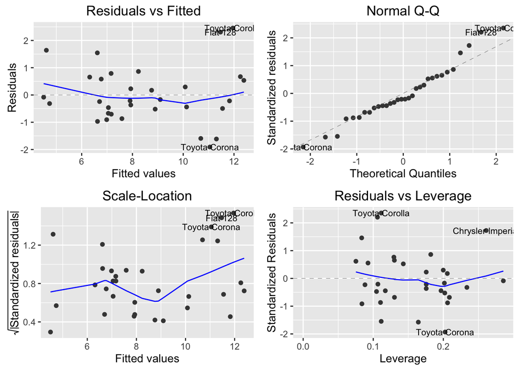

```r
autoplot(fit6, label.size = 3)
```

# Ejercicio 3

Reproducir la figura 13 del libro *Why Information Grows*. Luego realizar una regresión adecuada e interpretar.

# Desarrollo ejercicio

## Figure 13a. GDP per capita versus export diversity for year 2000.

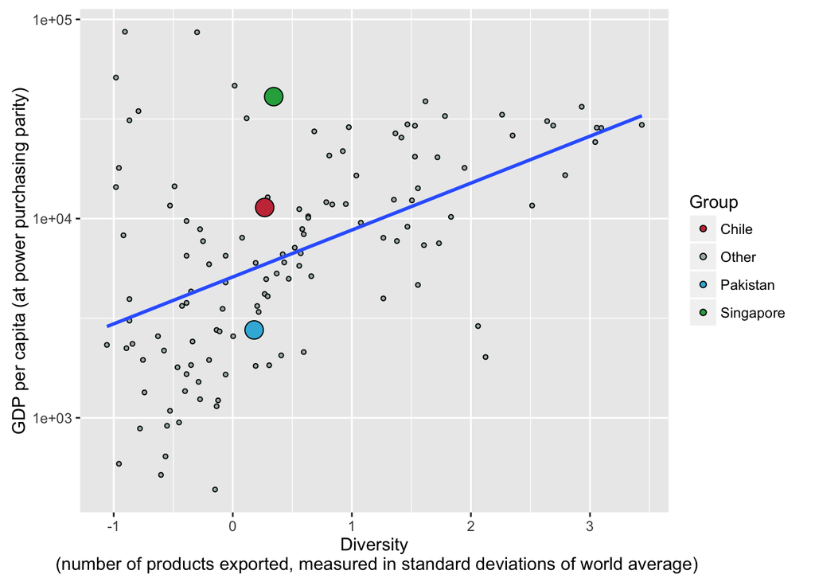

```r
data <- readWorksheetFromFile("year_2000_data.xlsx", sheet = "Sheet1", region = "A1:I125")
pal <- c("#c93845", "#a6b6b6", "#3ab6dc", "#28aa4d")

fig13a <- ggplot(data, aes(x = diversity, y = GDP_PC_PPP, fill = Group, size = I(Size))) +
  geom_point(shape = 21) +
  scale_y_log10() +
  labs(x = "Diversity\n (number of products exported, measured in standard deviations of world average)",
       y = "GDP per capita (at power purchasing parity)") +
  scale_fill_manual(values = pal) +
  geom_smooth(method=lm, se=FALSE, show_guide=FALSE)
fig13a
```

## Figure 13b. GDP per capita versus economic complexity for year 2000.

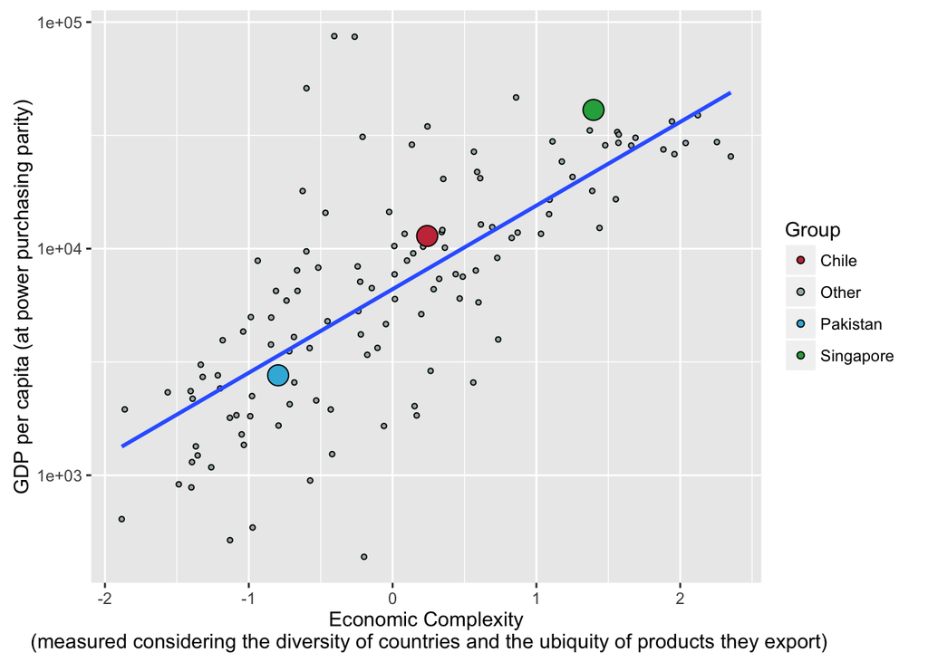

```r
fig13b <- ggplot(data, aes(x = ECI, y = GDP_PC_PPP, fill = Group, size = I(Size))) +
  geom_point(shape = 21) +
  scale_y_log10() +
  labs(x = "Economic Complexity\n (measured considering the diversity of countries and the ubiquity of products they export)",
       y = "GDP per capita (at power purchasing parity)") +
  scale_fill_manual(values = pal) +
  geom_smooth(method=lm, se=FALSE, show_guide=FALSE)
fig13b
```

```r
fit1 <- lm(GDP_PC_PPP ~ diversity, data)
fit2 <- lm(GDP_PC_PPP ~ ECI, data)
summary(fit1)
```

```
##
## Call:
## lm(formula = GDP_PC_PPP ~ diversity, data = data)
##
## Residuals:
##    Min     1Q Median     3Q    Max
## -16711  -7682  -5236   2889  79302
##
## Coefficients:
##             Estimate Std. Error t value Pr(>|t|)
## (Intercept)    10780       1411   7.642 5.41e-12 ***
## diversity       3745       1188   3.151  0.00205 **
## ---
## Signif. codes:  0 '***' 0.001 '**' 0.01 '*' 0.05 '.' 0.1 ' ' 1
##
## Residual standard error: 14370 on 122 degrees of freedom
## Multiple R-squared:  0.07526,    Adjusted R-squared:  0.06768
## F-statistic: 9.928 on 1 and 122 DF,  p-value: 0.002048
```

```r
summary(fit2)
```

```
##
## Call:
## lm(formula = GDP_PC_PPP ~ ECI, data = data)
##
## Residuals:
##    Min     1Q Median     3Q    Max
## -14250  -5627  -2356   1295  77273
##
## Coefficients:
##             Estimate Std. Error t value Pr(>|t|)
## (Intercept)    12521       1145  10.934  < 2e-16 ***
## ECI             7655       1135   6.742 5.52e-10 ***
## ---
## Signif. codes:  0 '***' 0.001 '**' 0.01 '*' 0.05 '.' 0.1 ' ' 1
##
## Residual standard error: 12750 on 122 degrees of freedom
## Multiple R-squared:  0.2715, Adjusted R-squared:  0.2655
## F-statistic: 45.46 on 1 and 122 DF,  p-value: 5.519e-10
```